# IE 582 - Homework III

## Seval Ata

### 20.11.2019

**Part A**

*Necessary libraries and reading the data*

```r
library(readxl)
library(data.table)
library(tidyr)
library(glmnet)
```

```r
consumption <- read_excel("/Users/Seval/Desktop/2019-2020/HW3/GercekZamanliTuketim.xls")
names(consumption)
```

1. 'Tarih'

2. 'Saat'

3. 'Tuketim Miktari'

*Renaming and reordering the data columns*

```r
names(consumption)[1]="Date"
names(consumption)[2]="Dummy"
names(consumption)[3]="Consumption"
```

```r
consumption_split<- strsplit(as.character(consumption$Dummy), split=" ")
consumption <- transform(consumption, Dummy2= sapply(consumption_split, "[[", 1),Time= sapply(consumption_split, "[[", 2))
```

```r
consumption.df<-data.table(consumption)
consumption.df[,c("Dummy","Dummy2"):=NULL]
consumption.df<- consumption.df[, c(1, 3, 2)]
```

*Creating new columns for the Date and Consumption values of Lag48 and Lag168.*

```r
consumption.df[,lag48_Date:=Date-60*60*24*2]
consumption.df[,lag48_Consumption:= 0]
consumption.df[,lag168_Date:=Date-60*60*24*7]
consumption.df[,lag168_Consumption:= 0]
```

*Filling the consumption columns for Lag48 and Lag168.*

```r
for(i in 49:(dim(consumption.df)[1])){
    consumption.df$lag48_Consumption[i]<-consumption.df$Consumption[i-48]
}
```

```r
for(i in 169:(dim(consumption.df)[1])){
    consumption.df$lag168_Consumption[i]<-consumption.df$Consumption[i-168]
}
```

*Final data table*

```r
consumption.df
```

| Date | Time | Consumption | lag48_Date | lag48_Consumption | lag168_Date | lag168_Consumption |
| --- | --- | --- | --- | --- | --- | --- |
| 2016-11-01 | 00:00:00 | 28032.45 | 2016-10-30 | 0 | 2016-10-25 | 0 |
| 2016-11-01 | 01:00:00 | 26515.65 | 2016-10-30 | 0 | 2016-10-25 | 0 |
| 2016-11-01 | 02:00:00 | 25687.16 | 2016-10-30 | 0 | 2016-10-25 | 0 |
| 2016-11-01 | 03:00:00 | 25152.53 | 2016-10-30 | 0 | 2016-10-25 | 0 |
| 2016-11-01 | 04:00:00 | 24903.70 | 2016-10-30 | 0 | 2016-10-25 | 0 |
| 2016-11-01 | 05:00:00 | 25197.38 | 2016-10-30 | 0 | 2016-10-25 | 0 |
| 2016-11-01 | 06:00:00 | 25965.52 | 2016-10-30 | 0 | 2016-10-25 | 0 |
| 2016-11-01 | 07:00:00 | 27573.40 | 2016-10-30 | 0 | 2016-10-25 | 0 |
| 2016-11-01 | 08:00:00 | 31815.96 | 2016-10-30 | 0 | 2016-10-25 | 0 |
| 2016-11-01 | 09:00:00 | 34528.60 | 2016-10-30 | 0 | 2016-10-25 | 0 |
| 2016-11-01 | 10:00:00 | 35355.73 | 2016-10-30 | 0 | 2016-10-25 | 0 |
| 2016-11-01 | 11:00:00 | 35600.34 | 2016-10-30 | 0 | 2016-10-25 | 0 |
| 2016-11-01 | 12:00:00 | 34043.03 | 2016-10-30 | 0 | 2016-10-25 | 0 |
| 2016-11-01 | 13:00:00 | 34592.09 | 2016-10-30 | 0 | 2016-10-25 | 0 |
| 2016-11-01 | 14:00:00 | 35069.03 | 2016-10-30 | 0 | 2016-10-25 | 0 |
| 2016-11-01 | 15:00:00 | 34718.82 | 2016-10-30 | 0 | 2016-10-25 | 0 |
| 2016-11-01 | 16:00:00 | 34934.69 | 2016-10-30 | 0 | 2016-10-25 | 0 |
| 2016-11-01 | 17:00:00 | 35278.73 | 2016-10-30 | 0 | 2016-10-25 | 0 |
| 2016-11-01 | 18:00:00 | 35589.85 | 2016-10-30 | 0 | 2016-10-25 | 0 |
| 2016-11-01 | 19:00:00 | 34449.39 | 2016-10-30 | 0 | 2016-10-25 | 0 |
| 2016-11-01 | 20:00:00 | 33620.31 | 2016-10-30 | 0 | 2016-10-25 | 0 |
| 2016-11-01 | 21:00:00 | 32630.86 | 2016-10-30 | 0 | 2016-10-25 | 0 |
| 2016-11-01 | 22:00:00 | 32148.63 | 2016-10-30 | 0 | 2016-10-25 | 0 |
| 2016-11-01 | 23:00:00 | 30647.12 | 2016-10-30 | 0 | 2016-10-25 | 0 |
| 2016-11-02 | 00:00:00 | 28443.75 | 2016-10-31 | 0 | 2016-10-26 | 0 |
| 2016-11-02 | 01:00:00 | 26987.62 | 2016-10-31 | 0 | 2016-10-26 | 0 |
| 2016-11-02 | 02:00:00 | 26131.66 | 2016-10-31 | 0 | 2016-10-26 | 0 |
| 2016-11-02 | 03:00:00 | 25655.50 | 2016-10-31 | 0 | 2016-10-26 | 0 |
| 2016-11-02 | 04:00:00 | 25268.47 | 2016-10-31 | 0 | 2016-10-26 | 0 |
| 2016-11-02 | 05:00:00 | 25752.35 | 2016-10-31 | 0 | 2016-10-26 | 0 |
| ... | ... | ... | ... | ... | ... | ... |
| 2019-10-31 | 18:00:00 | 37199.82 | 2019-10-29 | 32634.84 | 2019-10-24 | 36896.34 |
| 2019-10-31 | 19:00:00 | 36104.42 | 2019-10-29 | 32073.46 | 2019-10-24 | 36101.45 |
| 2019-10-31 | 20:00:00 | 35263.31 | 2019-10-29 | 31545.44 | 2019-10-24 | 35323.94 |
| 2019-10-31 | 21:00:00 | 34133.64 | 2019-10-29 | 30666.96 | 2019-10-24 | 34256.95 |
| 2019-10-31 | 22:00:00 | 32865.22 | 2019-10-29 | 29559.34 | 2019-10-24 | 33052.27 |
| 2019-10-31 | 23:00:00 | 31399.91 | 2019-10-29 | 28434.09 | 2019-10-24 | 31544.26 |
| 2019-11-01 | 00:00:00 | 29417.56 | 2019-10-30 | 27154.21 | 2019-10-25 | 29563.43 |
| 2019-11-01 | 01:00:00 | 28133.75 | 2019-10-30 | 26157.42 | 2019-10-25 | 28242.90 |
| 2019-11-01 | 02:00:00 | 27358.60 | 2019-10-30 | 25373.88 | 2019-10-25 | 27258.74 |
| 2019-11-01 | 03:00:00 | 26780.09 | 2019-10-30 | 24911.43 | 2019-10-25 | 26739.84 |
| 2019-11-01 | 04:00:00 | 26511.54 | 2019-10-30 | 24836.11 | 2019-10-25 | 26555.35 |
| 2019-11-01 | 05:00:00 | 27002.74 | 2019-10-30 | 25233.76 | 2019-10-25 | 26857.36 |
| 2019-11-01 | 06:00:00 | 27945.43 | 2019-10-30 | 26296.00 | 2019-10-25 | 27783.77 |
| 2019-11-01 | 07:00:00 | 29120.27 | 2019-10-30 | 27575.60 | 2019-10-25 | 28969.45 |
| 2019-11-01 | 08:00:00 | 32815.46 | 2019-10-30 | 31667.27 | 2019-10-25 | 32153.21 |
| 2019-11-01 | 09:00:00 | 34569.09 | 2019-10-30 | 33138.17 | 2019-10-25 | 33615.22 |
| 2019-11-01 | 10:00:00 | 35091.43 | 2019-10-30 | 32926.25 | 2019-10-25 | 33398.50 |
| 2019-11-01 | 11:00:00 | 35416.33 | 2019-10-30 | 33122.35 | 2019-10-25 | 33542.88 |
| 2019-11-01 | 12:00:00 | 33184.81 | 2019-10-30 | 31518.65 | 2019-10-25 | 30839.72 |
| 2019-11-01 | 13:00:00 | 33549.94 | 2019-10-30 | 31895.21 | 2019-10-25 | 30920.91 |
| 2019-11-01 | 14:00:00 | 35732.88 | 2019-10-30 | 33050.83 | 2019-10-25 | 33019.99 |
| 2019-11-01 | 15:00:00 | 35859.75 | 2019-10-30 | 33464.69 | 2019-10-25 | 33476.62 |
| 2019-11-01 | 16:00:00 | 36268.51 | 2019-10-30 | 34612.24 | 2019-10-25 | 34304.06 |
| 2019-11-01 | 17:00:00 | 37011.89 | 2019-10-30 | 36082.10 | 2019-10-25 | 35973.89 |
| 2019-11-01 | 18:00:00 | 37199.91 | 2019-10-30 | 36936.24 | 2019-10-25 | 36302.11 |
| 2019-11-01 | 19:00:00 | 36056.96 | 2019-10-30 | 36219.71 | 2019-10-25 | 35698.70 |
| 2019-11-01 | 20:00:00 | 35130.19 | 2019-10-30 | 35136.55 | 2019-10-25 | 34820.93 |
| 2019-11-01 | 21:00:00 | 33947.64 | 2019-10-30 | 34155.15 | 2019-10-25 | 33659.48 |
| 2019-11-01 | 22:00:00 | 32877.69 | 2019-10-30 | 32878.23 | 2019-10-25 | 32696.81 |
| 2019-11-01 | 23:00:00 | 31590.75 | 2019-10-30 | 31456.46 | 2019-10-25 | 30942.64 |

We are going to use the test data as the dates after 1st of November, 2019 (included). As the train data, we are going to use the rest of the data but since there are no lag168_Consumption data for the first 168 row, we are going to eliminate them.

```r
test_data=consumption.df[Date>="2019-11-01"]
train_data=consumption.df[Date < "2019-11-01"]
train_data=train_data[169:dim(train_data)[1]]
```

**MAPE of the Naive Forecasts.**

```r
MAPE_lag48=0
MAPE_lag168=0

MAPE_lag48=sum(abs(test_data$Consumption-test_data$lag48_Consumption)/test_data$Consumption)/dim(test_data)[1]
MAPE_lag168=sum(abs(test_data$Consumption-test_data$lag168_Consumption)/test_data$Consumption)/dim(test_data)[1]

MAPE_lag48
MAPE_lag168
```

0.0444778419008971

0.0263293095245023

We can see that lag168 consumption values are better forecasts than lag48 values.

**Part B**

*The linear regression model includes aforementioned two features (lag48_Consumption and lag168_Consumption) and an intercept.*

```r
lm_consumption=lm(Consumption~lag48_Consumption+lag168_Consumption,train_data)
```

```r
summary(lm_consumption)
```

```
Call:
lm(formula = Consumption ~ lag48_Consumption + lag168_Consumption,
    data = train_data)

Residuals:
     Min       1Q   Median       3Q      Max
-16361.8   -988.9     -1.1   1011.8  16141.9

Coefficients:
                    Estimate Std. Error t value Pr(>|t|)
(Intercept)        1.642e+03  1.120e+02   14.67   <2e-16 ***
lag48_Consumption  2.997e-01  3.918e-03   76.49   <2e-16 ***
lag168_Consumption 6.507e-01  3.923e-03  165.86   <2e-16 ***
---
Signif. codes:  0 ‘***’ 0.001 ‘**’ 0.01 ‘*’ 0.05 ‘.’ 0.1 ‘ ’ 1

Residual standard error: 2379 on 26109 degrees of freedom
Multiple R-squared:  0.7611,	Adjusted R-squared:  0.7611
F-statistic: 4.158e+04 on 2 and 26109 DF,  p-value: < 2.2e-16
```

```r
lm_consumption$coefficients
```

**(Intercept)**

1642.34421409844

**lag48_Consumption**

0.29972324081469

**lag168_Consumption**

0.650685671438464

```
So, the predictions for the consumption amount for the dates after 1st of November, 2019 is given as:
```

**Consumption = 1642.34421409844 + 0.29972324081469 x lag48_Consumption + 0.650685671438464 x lag168_Consumption**

```r
test_data[,lm_Prediction:=lm_consumption$coefficients[1]+lm_consumption$coefficients[2]*lag48_Consumption+lm_consumption$coefficients[3]*lag168_Consumption]
```

```r
test_data
```

| Date | Time | Consumption | lag48_Date | lag48_Consumption | lag168_Date | lag168_Consumption | lm_Prediction |
| --- | --- | --- | --- | --- | --- | --- | --- |
| 2019-11-01 | 00:00:00 | 29417.56 | 2019-10-30 | 27154.21 | 2019-10-25 | 29563.43 | 29017.59 |
| 2019-11-01 | 01:00:00 | 28133.75 | 2019-10-30 | 26157.42 | 2019-10-25 | 28242.90 | 27859.58 |
| 2019-11-01 | 02:00:00 | 27358.60 | 2019-10-30 | 25373.88 | 2019-10-25 | 27258.74 | 26984.36 |
| 2019-11-01 | 03:00:00 | 26780.09 | 2019-10-30 | 24911.43 | 2019-10-25 | 26739.84 | 26508.11 |
| 2019-11-01 | 04:00:00 | 26511.54 | 2019-10-30 | 24836.11 | 2019-10-25 | 26555.35 | 26365.49 |
| 2019-11-01 | 05:00:00 | 27002.74 | 2019-10-30 | 25233.76 | 2019-10-25 | 26857.36 | 26681.19 |
| 2019-11-01 | 06:00:00 | 27945.43 | 2019-10-30 | 26296.00 | 2019-10-25 | 27783.77 | 27602.37 |
| 2019-11-01 | 07:00:00 | 29120.27 | 2019-10-30 | 27575.60 | 2019-10-25 | 28969.45 | 28757.40 |
| 2019-11-01 | 08:00:00 | 32815.46 | 2019-10-30 | 31667.27 | 2019-10-25 | 32153.21 | 32055.39 |
| 2019-11-01 | 09:00:00 | 34569.09 | 2019-10-30 | 33138.17 | 2019-10-25 | 33615.22 | 33447.57 |
| 2019-11-01 | 10:00:00 | 35091.43 | 2019-10-30 | 32926.25 | 2019-10-25 | 33398.50 | 33243.03 |
| 2019-11-01 | 11:00:00 | 35416.33 | 2019-10-30 | 33122.35 | 2019-10-25 | 33542.88 | 33395.75 |
| 2019-11-01 | 12:00:00 | 33184.81 | 2019-10-30 | 31518.65 | 2019-10-25 | 30839.72 | 31156.18 |
| 2019-11-01 | 13:00:00 | 33549.94 | 2019-10-30 | 31895.21 | 2019-10-25 | 30920.91 | 31321.87 |
| 2019-11-01 | 14:00:00 | 35732.88 | 2019-10-30 | 33050.83 | 2019-10-25 | 33019.99 | 33034.08 |
| 2019-11-01 | 15:00:00 | 35859.75 | 2019-10-30 | 33464.69 | 2019-10-25 | 33476.62 | 33455.25 |
| 2019-11-01 | 16:00:00 | 36268.51 | 2019-10-30 | 34612.24 | 2019-10-25 | 34304.06 | 34337.60 |
| 2019-11-01 | 17:00:00 | 37011.89 | 2019-10-30 | 36082.10 | 2019-10-25 | 35973.89 | 35864.68 |
| 2019-11-01 | 18:00:00 | 37199.91 | 2019-10-30 | 36936.24 | 2019-10-25 | 36302.11 | 36334.26 |
| 2019-11-01 | 19:00:00 | 36056.96 | 2019-10-30 | 36219.71 | 2019-10-25 | 35698.70 | 35726.87 |
| 2019-11-01 | 20:00:00 | 35130.19 | 2019-10-30 | 35136.55 | 2019-10-25 | 34820.93 | 34831.07 |
| 2019-11-01 | 21:00:00 | 33947.64 | 2019-10-30 | 34155.15 | 2019-10-25 | 33659.48 | 33781.18 |
| 2019-11-01 | 22:00:00 | 32877.69 | 2019-10-30 | 32878.23 | 2019-10-25 | 32696.81 | 32772.06 |
| 2019-11-01 | 23:00:00 | 31590.75 | 2019-10-30 | 31456.46 | 2019-10-25 | 30942.64 | 31204.51 |

```r
MAPE_lm=sum(abs(test_data$Consumption-test_data$lm_Prediction)/test_data$Consumption)/dim(test_data)[1]
MAPE_lm
```

0.0279292120545463

**Part C**

Here we are going to train linear regression models for each hour using the same training period (24 models).

*Separating data for each hour*

```r
hour0=train_data[Time=="00:00:00"]
hour1=train_data[Time=="01:00:00"]
hour2=train_data[Time=="02:00:00"]
hour3=train_data[Time=="03:00:00"]
hour4=train_data[Time=="04:00:00"]
hour5=train_data[Time=="05:00:00"]
hour6=train_data[Time=="06:00:00"]
hour7=train_data[Time=="07:00:00"]
hour8=train_data[Time=="08:00:00"]
hour9=train_data[Time=="09:00:00"]
hour10=train_data[Time=="10:00:00"]
hour11=train_data[Time=="11:00:00"]
hour12=train_data[Time=="12:00:00"]
hour13=train_data[Time=="13:00:00"]
hour14=train_data[Time=="14:00:00"]
hour15=train_data[Time=="15:00:00"]
hour16=train_data[Time=="16:00:00"]
hour17=train_data[Time=="17:00:00"]
hour18=train_data[Time=="18:00:00"]
hour19=train_data[Time=="19:00:00"]
hour20=train_data[Time=="20:00:00"]
hour21=train_data[Time=="21:00:00"]
hour22=train_data[Time=="22:00:00"]
hour23=train_data[Time=="23:00:00"]
```

*Linear models are built for each hour.*

```r
lm_h0=lm(Consumption~lag48_Consumption+lag168_Consumption,hour0)
lm_h1=lm(Consumption~lag48_Consumption+lag168_Consumption,hour1)
lm_h2=lm(Consumption~lag48_Consumption+lag168_Consumption,hour2)
lm_h3=lm(Consumption~lag48_Consumption+lag168_Consumption,hour3)
lm_h4=lm(Consumption~lag48_Consumption+lag168_Consumption,hour4)
lm_h5=lm(Consumption~lag48_Consumption+lag168_Consumption,hour5)
lm_h6=lm(Consumption~lag48_Consumption+lag168_Consumption,hour6)
lm_h7=lm(Consumption~lag48_Consumption+lag168_Consumption,hour7)
lm_h8=lm(Consumption~lag48_Consumption+lag168_Consumption,hour8)
lm_h9=lm(Consumption~lag48_Consumption+lag168_Consumption,hour9)
lm_h10=lm(Consumption~lag48_Consumption+lag168_Consumption,hour10)
lm_h11=lm(Consumption~lag48_Consumption+lag168_Consumption,hour11)
lm_h12=lm(Consumption~lag48_Consumption+lag168_Consumption,hour12)
lm_h13=lm(Consumption~lag48_Consumption+lag168_Consumption,hour13)
lm_h14=lm(Consumption~lag48_Consumption+lag168_Consumption,hour14)
lm_h15=lm(Consumption~lag48_Consumption+lag168_Consumption,hour15)
lm_h16=lm(Consumption~lag48_Consumption+lag168_Consumption,hour16)
lm_h17=lm(Consumption~lag48_Consumption+lag168_Consumption,hour17)
lm_h18=lm(Consumption~lag48_Consumption+lag168_Consumption,hour18)
lm_h19=lm(Consumption~lag48_Consumption+lag168_Consumption,hour19)
lm_h20=lm(Consumption~lag48_Consumption+lag168_Consumption,hour20)
lm_h21=lm(Consumption~lag48_Consumption+lag168_Consumption,hour21)
lm_h22=lm(Consumption~lag48_Consumption+lag168_Consumption,hour22)
lm_h23=lm(Consumption~lag48_Consumption+lag168_Consumption,hour23)
```

*New column is created for the predictions.*

```r
test_data[,lm_Hourly_Prediction:=0]
```

*The forecasts using the linear models for each hour is used for prediction.*

```r
test_data$lm_Hourly_Prediction[1]=lm_h0$coefficients[1]+lm_h0$coefficients[2]*test_data$lag48_Consumption[1]+lm_h0$coefficients[3]*test_data$lag168_Consumption[1]
test_data$lm_Hourly_Prediction[2]=lm_h1$coefficients[1]+lm_h0$coefficients[2]*test_data$lag48_Consumption[2]+lm_h0$coefficients[3]*test_data$lag168_Consumption[2]
test_data$lm_Hourly_Prediction[3]=lm_h2$coefficients[1]+lm_h0$coefficients[2]*test_data$lag48_Consumption[3]+lm_h0$coefficients[3]*test_data$lag168_Consumption[3]
test_data$lm_Hourly_Prediction[4]=lm_h3$coefficients[1]+lm_h0$coefficients[2]*test_data$lag48_Consumption[4]+lm_h0$coefficients[3]*test_data$lag168_Consumption[4]
test_data$lm_Hourly_Prediction[5]=lm_h4$coefficients[1]+lm_h0$coefficients[2]*test_data$lag48_Consumption[5]+lm_h0$coefficients[3]*test_data$lag168_Consumption[5]
test_data$lm_Hourly_Prediction[6]=lm_h5$coefficients[1]+lm_h0$coefficients[2]*test_data$lag48_Consumption[6]+lm_h0$coefficients[3]*test_data$lag168_Consumption[6]
test_data$lm_Hourly_Prediction[7]=lm_h6$coefficients[1]+lm_h0$coefficients[2]*test_data$lag48_Consumption[7]+lm_h0$coefficients[3]*test_data$lag168_Consumption[7]
test_data$lm_Hourly_Prediction[8]=lm_h7$coefficients[1]+lm_h0$coefficients[2]*test_data$lag48_Consumption[8]+lm_h0$coefficients[3]*test_data$lag168_Consumption[8]
test_data$lm_Hourly_Prediction[9]=lm_h8$coefficients[1]+lm_h0$coefficients[2]*test_data$lag48_Consumption[9]+lm_h0$coefficients[3]*test_data$lag168_Consumption[9]
test_data$lm_Hourly_Prediction[10]=lm_h9$coefficients[1]+lm_h0$coefficients[2]*test_data$lag48_Consumption[10]+lm_h0$coefficients[3]*test_data$lag168_Consumption[10]
test_data$lm_Hourly_Prediction[11]=lm_h10$coefficients[1]+lm_h0$coefficients[2]*test_data$lag48_Consumption[11]+lm_h0$coefficients[3]*test_data$lag168_Consumption[11]
test_data$lm_Hourly_Prediction[12]=lm_h11$coefficients[1]+lm_h0$coefficients[2]*test_data$lag48_Consumption[12]+lm_h0$coefficients[3]*test_data$lag168_Consumption[12]
test_data$lm_Hourly_Prediction[13]=lm_h12$coefficients[1]+lm_h0$coefficients[2]*test_data$lag48_Consumption[13]+lm_h0$coefficients[3]*test_data$lag168_Consumption[13]
test_data$lm_Hourly_Prediction[14]=lm_h13$coefficients[1]+lm_h0$coefficients[2]*test_data$lag48_Consumption[14]+lm_h0$coefficients[3]*test_data$lag168_Consumption[14]
test_data$lm_Hourly_Prediction[15]=lm_h14$coefficients[1]+lm_h0$coefficients[2]*test_data$lag48_Consumption[15]+lm_h0$coefficients[3]*test_data$lag168_Consumption[15]
test_data$lm_Hourly_Prediction[16]=lm_h15$coefficients[1]+lm_h0$coefficients[2]*test_data$lag48_Consumption[16]+lm_h0$coefficients[3]*test_data$lag168_Consumption[16]
test_data$lm_Hourly_Prediction[17]=lm_h16$coefficients[1]+lm_h0$coefficients[2]*test_data$lag48_Consumption[17]+lm_h0$coefficients[3]*test_data$lag168_Consumption[17]
test_data$lm_Hourly_Prediction[18]=lm_h17$coefficients[1]+lm_h0$coefficients[2]*test_data$lag48_Consumption[18]+lm_h0$coefficients[3]*test_data$lag168_Consumption[18]
test_data$lm_Hourly_Prediction[19]=lm_h18$coefficients[1]+lm_h0$coefficients[2]*test_data$lag48_Consumption[19]+lm_h0$coefficients[3]*test_data$lag168_Consumption[19]
test_data$lm_Hourly_Prediction[20]=lm_h19$coefficients[1]+lm_h0$coefficients[2]*test_data$lag48_Consumption[20]+lm_h0$coefficients[3]*test_data$lag168_Consumption[20]
test_data$lm_Hourly_Prediction[21]=lm_h20$coefficients[1]+lm_h0$coefficients[2]*test_data$lag48_Consumption[21]+lm_h0$coefficients[3]*test_data$lag168_Consumption[21]
test_data$lm_Hourly_Prediction[22]=lm_h21$coefficients[1]+lm_h0$coefficients[2]*test_data$lag48_Consumption[22]+lm_h0$coefficients[3]*test_data$lag168_Consumption[22]
test_data$lm_Hourly_Prediction[23]=lm_h22$coefficients[1]+lm_h0$coefficients[2]*test_data$lag48_Consumption[23]+lm_h0$coefficients[3]*test_data$lag168_Consumption[23]
test_data$lm_Hourly_Prediction[24]=lm_h23$coefficients[1]+lm_h0$coefficients[2]*test_data$lag48_Consumption[24]+lm_h0$coefficients[3]*test_data$lag168_Consumption[24]
```

```r
MAPE_lm_hourly=sum(abs(test_data$Consumption-test_data$lm_Hourly_Prediction)/test_data$Consumption)/dim(test_data)[1]
MAPE_lm_hourly
```

0.0157844740460675

**Part D**

*Preparation of data in the wide format*

```r
data_wide=consumption.df
```

```r
data_wide[,lag48_Date:=NULL]
data_wide[,lag168_Date:=NULL]
data_wide[,lag48_Consumption:=NULL]
data_wide[,lag168_Consumption:=NULL]
```

```r
data_wide<- spread(data_wide, Time, Consumption)
data_wide
```

| Date | 00:00:00 | 01:00:00 | 02:00:00 | 03:00:00 | 04:00:00 | 05:00:00 | 06:00:00 | 07:00:00 | 08:00:00 | ... | 14:00:00 | 15:00:00 | 16:00:00 | 17:00:00 | 18:00:00 | 19:00:00 | 20:00:00 | 21:00:00 | 22:00:00 | 23:00:00 |
| --- | --- | --- | --- | --- | --- | --- | --- | --- | --- | --- | --- | --- | --- | --- | --- | --- | --- | --- | --- | --- |
| 2016-11-01 | 28032.45 | 26515.65 | 25687.16 | 25152.53 | 24903.70 | 25197.38 | 25965.52 | 27573.40 | 31815.96 | ... | 35069.03 | 34718.82 | 34934.69 | 35278.73 | 35589.85 | 34449.39 | 33620.31 | 32630.86 | 32148.63 | 30647.12 |
| 2016-11-02 | 28443.75 | 26987.62 | 26131.66 | 25655.50 | 25268.47 | 25752.35 | 26715.97 | 28421.31 | 32653.72 | ... | 35030.24 | 34664.89 | 34725.83 | 35367.85 | 36114.10 | 35622.12 | 34818.21 | 33833.66 | 33166.59 | 31708.78 |
| 2016-11-03 | 29121.03 | 27665.55 | 26689.57 | 26057.45 | 25730.03 | 26503.83 | 27406.71 | 29047.66 | 33244.35 | ... | 34569.26 | 34185.81 | 34376.30 | 35192.63 | 36169.75 | 35507.07 | 34678.88 | 33825.89 | 33086.19 | 31618.59 |
| 2016-11-04 | 29024.93 | 27753.29 | 26432.15 | 25943.66 | 25670.40 | 26223.43 | 27552.35 | 29084.00 | 33183.49 | ... | 35273.14 | 34835.68 | 35034.60 | 35809.91 | 36367.53 | 35389.82 | 34410.85 | 33275.09 | 32793.00 | 31562.25 |
| 2016-11-05 | 29241.68 | 27802.16 | 26585.33 | 26006.92 | 25796.40 | 25947.40 | 26505.31 | 27193.91 | 30401.78 | ... | 32757.32 | 32139.61 | 31807.34 | 32672.77 | 34061.74 | 33312.47 | 32485.60 | 31782.61 | 31281.05 | 29766.51 |
| 2016-11-06 | 27756.16 | 26152.01 | 24948.29 | 24485.74 | 24102.25 | 24185.83 | 24293.39 | 23736.54 | 24640.05 | ... | 27480.03 | 27235.76 | 27411.49 | 28926.80 | 31132.40 | 30949.32 | 30522.79 | 29838.59 | 29282.05 | 27671.45 |
| 2016-11-07 | 26041.10 | 24669.75 | 24048.99 | 23347.38 | 23400.79 | 23864.99 | 25530.12 | 27609.98 | 31898.48 | ... | 34239.96 | 34115.60 | 34938.23 | 35121.84 | 35396.59 | 34380.33 | 33520.54 | 32714.34 | 31847.48 | 30295.86 |
| 2016-11-08 | 28289.42 | 26909.99 | 26033.37 | 25521.27 | 25434.25 | 25747.41 | 26847.36 | 28384.51 | 32425.54 | ... | 34000.72 | 33612.86 | 33687.50 | 34416.41 | 34830.20 | 33860.74 | 33226.17 | 32292.83 | 31522.61 | 30215.19 |
| 2016-11-09 | 28169.88 | 26842.45 | 26041.27 | 25594.72 | 25431.54 | 25786.26 | 26829.46 | 28338.69 | 31998.44 | ... | 34084.92 | 33670.62 | 33704.98 | 34574.32 | 34867.00 | 33963.82 | 33048.78 | 32192.10 | 31308.69 | 30088.98 |
| 2016-11-10 | 28043.85 | 26697.08 | 25699.63 | 25320.29 | 25205.27 | 25561.88 | 26627.44 | 28121.14 | 31762.78 | ... | 34115.60 | 33723.35 | 33741.92 | 34282.73 | 35017.89 | 34194.08 | 33331.31 | 32351.56 | 31895.64 | 30624.21 |
| 2016-11-11 | 28406.63 | 26930.13 | 25798.84 | 25726.06 | 25445.79 | 25802.05 | 26440.88 | 28332.59 | 31842.83 | ... | 33501.23 | 33231.64 | 33537.67 | 34333.68 | 34605.21 | 33781.16 | 32956.85 | 32216.92 | 31582.88 | 30700.37 |
| 2016-11-12 | 28592.65 | 27126.19 | 26030.55 | 25122.95 | 25264.01 | 25454.93 | 25866.72 | 26869.65 | 29819.21 | ... | 31899.60 | 31202.62 | 31115.72 | 31812.64 | 32950.41 | 32280.42 | 31594.76 | 30958.15 | 30461.56 | 29013.99 |
| 2016-11-13 | 27417.65 | 25857.95 | 24451.00 | 23926.44 | 23656.88 | 23672.10 | 23745.51 | 23326.12 | 23916.40 | ... | 27329.71 | 27236.65 | 27533.85 | 28695.32 | 30353.32 | 30175.16 | 29801.85 | 29289.56 | 28861.39 | 27612.14 |
| 2016-11-14 | 25902.55 | 24629.22 | 23576.41 | 23264.37 | 23183.46 | 23634.20 | 24964.14 | 27044.45 | 31641.70 | ... | 34785.98 | 34500.88 | 34767.50 | 35800.73 | 35780.17 | 34643.68 | 34118.53 | 33091.63 | 32375.75 | 30964.22 |
| 2016-11-15 | 28743.84 | 27342.45 | 26293.71 | 25704.91 | 25611.94 | 26043.47 | 27088.20 | 28903.21 | 33068.16 | ... | 36075.57 | 35692.81 | 35895.78 | 36652.62 | 36586.33 | 35510.57 | 34571.32 | 33645.50 | 32977.72 | 31540.68 |
| 2016-11-16 | 29114.75 | 27620.91 | 26590.51 | 26133.03 | 26032.88 | 26365.35 | 27446.72 | 29285.02 | 33514.86 | ... | 36824.00 | 36530.13 | 36730.43 | 37611.70 | 37302.11 | 36210.85 | 35101.71 | 34139.19 | 33420.47 | 31929.50 |
| 2016-11-17 | 29552.15 | 27742.90 | 26739.00 | 26218.27 | 26028.40 | 26424.68 | 27624.23 | 29631.82 | 33764.41 | ... | 35947.97 | 35629.11 | 36090.10 | 37117.58 | 37428.41 | 36502.75 | 35494.16 | 34493.89 | 33644.77 | 31916.32 |
| 2016-11-18 | 29713.65 | 27784.75 | 26870.65 | 26352.47 | 26123.57 | 26599.72 | 27879.64 | 29970.64 | 34054.11 | ... | 35166.67 | 35049.93 | 35437.17 | 36549.82 | 36912.34 | 36084.33 | 35349.38 | 34484.27 | 33881.96 | 32549.09 |
| 2016-11-19 | 30219.53 | 28326.28 | 27039.44 | 26374.86 | 26224.27 | 26441.62 | 27120.43 | 27926.03 | 31444.06 | ... | 33429.45 | 32885.96 | 32792.01 | 33986.31 | 35265.96 | 34572.11 | 33862.89 | 33010.62 | 32517.15 | 30929.11 |
| 2016-11-20 | 28722.00 | 26928.56 | 25584.49 | 24801.01 | 24431.66 | 24454.85 | 24689.39 | 24781.36 | 25579.12 | ... | 28135.66 | 28090.97 | 28474.08 | 30450.88 | 32281.73 | 32289.65 | 31725.37 | 30961.99 | 30534.52 | 29205.66 |
| 2016-11-21 | 27144.66 | 25562.36 | 24584.52 | 24108.06 | 24049.11 | 24508.04 | 25871.82 | 28272.31 | 32870.13 | ... | 35797.71 | 35679.17 | 35970.71 | 37315.06 | 37301.55 | 36286.13 | 35539.39 | 34330.38 | 33682.05 | 32146.84 |
| 2016-11-22 | 29641.77 | 27941.44 | 26889.15 | 26275.85 | 26233.38 | 26575.02 | 27819.71 | 29709.93 | 33942.60 | ... | 35466.40 | 35321.80 | 35888.83 | 37130.00 | 37347.56 | 36302.01 | 35451.37 | 34403.36 | 33772.99 | 32363.44 |
| 2016-11-23 | 29796.84 | 28184.01 | 27222.72 | 26620.37 | 26512.81 | 26887.12 | 28077.93 | 30085.11 | 34078.22 | ... | 36033.14 | 35751.88 | 36235.28 | 37548.76 | 37714.48 | 36589.42 | 35781.90 | 35049.31 | 34297.88 | 32735.33 |
| 2016-11-24 | 30488.20 | 28583.85 | 27380.81 | 26864.84 | 26464.85 | 27187.72 | 28081.69 | 30286.74 | 34159.36 | ... | 36162.95 | 35921.16 | 36232.21 | 37817.66 | 37835.70 | 36896.58 | 35947.65 | 35061.47 | 34489.33 | 33174.57 |
| 2016-11-25 | 30732.32 | 28453.74 | 27863.49 | 27258.41 | 27130.40 | 27388.28 | 28733.41 | 30766.13 | 34607.24 | ... | 35261.42 | 35594.68 | 36176.79 | 37149.05 | 37511.49 | 36304.14 | 35411.25 | 34524.11 | 33941.38 | 32593.41 |
| 2016-11-26 | 30508.74 | 28601.73 | 27398.64 | 26894.86 | 26713.21 | 26848.12 | 27492.19 | 28434.66 | 31449.55 | ... | 34021.14 | 33506.65 | 33532.78 | 34946.02 | 35784.04 | 34899.40 | 34116.64 | 33445.55 | 32869.18 | 31709.09 |
| 2016-11-27 | 29297.38 | 27414.53 | 25979.42 | 25425.66 | 25309.07 | 25213.82 | 25423.09 | 25423.74 | 25679.98 | ... | 28900.02 | 28696.09 | 29371.23 | 31322.66 | 32835.11 | 32599.19 | 32050.82 | 31643.50 | 30802.60 | 29874.24 |
| 2016-11-28 | 27493.29 | 25785.28 | 24795.56 | 24268.82 | 24526.83 | 24757.15 | 26105.30 | 28654.25 | 33321.99 | ... | 37155.18 | 36944.60 | 37592.34 | 38234.19 | 37704.60 | 36541.45 | 35734.00 | 34748.44 | 34020.40 | 32334.37 |
| 2016-11-29 | 30240.42 | 28187.44 | 27153.59 | 26792.41 | 26603.63 | 27114.70 | 28210.69 | 30239.42 | 34252.67 | ... | 38458.67 | 38329.21 | 38492.99 | 39118.86 | 38058.96 | 36744.92 | 35967.99 | 34863.26 | 34314.44 | 32882.66 |
| 2016-11-30 | 30401.59 | 28500.71 | 27036.79 | 26877.56 | 26810.02 | 27326.48 | 28633.09 | 30829.85 | 34988.47 | ... | 39455.88 | 39184.74 | 39157.78 | 39455.98 | 38421.22 | 37218.74 | 36340.90 | 35405.65 | 34983.98 | 33492.03 |
| ... | ... | ... | ... | ... | ... | ... | ... | ... | ... |  | ... | ... | ... | ... | ... | ... | ... | ... | ... | ... |
| 2019-10-03 | 30156.18 | 28840.52 | 28012.38 | 27467.55 | 27240.64 | 27491.50 | 27929.70 | 29006.96 | 32548.26 | ... | 35533.33 | 35717.09 | 36246.95 | 36781.67 | 36866.64 | 37272.52 | 36291.59 | 35018.16 | 33957.18 | 32420.60 |
| 2019-10-04 | 30464.48 | 29166.60 | 28059.80 | 27541.97 | 27356.75 | 27731.29 | 28173.00 | 29037.37 | 32608.56 | ... | 35353.24 | 35589.36 | 36243.35 | 36459.43 | 36699.52 | 36873.23 | 35597.62 | 34686.56 | 33570.35 | 32045.13 |
| 2019-10-05 | 30067.95 | 28397.56 | 27663.53 | 26742.70 | 26627.29 | 26813.64 | 26820.16 | 26863.76 | 29837.49 | ... | 32389.45 | 32195.70 | 32130.78 | 32524.87 | 33770.74 | 34563.17 | 33623.72 | 32606.53 | 31539.20 | 30076.26 |
| 2019-10-06 | 28180.12 | 26751.80 | 25797.09 | 25103.52 | 24775.74 | 24818.77 | 24376.33 | 23460.91 | 23870.75 | ... | 27151.29 | 27325.10 | 27692.15 | 28650.22 | 30547.06 | 31647.86 | 31254.60 | 30412.83 | 29535.63 | 28161.12 |
| 2019-10-07 | 26630.99 | 25555.75 | 24707.91 | 24322.41 | 24351.37 | 24679.76 | 25396.18 | 27060.81 | 30743.62 | ... | 34057.70 | 34260.94 | 34985.32 | 35160.25 | 35505.66 | 35578.82 | 34778.89 | 33689.22 | 32715.06 | 31232.77 |
| 2019-10-08 | 29292.17 | 27992.38 | 27164.87 | 26511.43 | 26440.79 | 26795.81 | 27277.71 | 28306.61 | 32086.98 | ... | 35140.39 | 35104.57 | 35668.98 | 36005.90 | 36365.97 | 36418.03 | 35349.16 | 34230.22 | 33209.52 | 31277.50 |
| 2019-10-09 | 29550.44 | 27993.66 | 27344.17 | 26906.26 | 26744.16 | 27066.71 | 27554.25 | 28481.88 | 32131.33 | ... | 33739.04 | 34098.15 | 34755.55 | 35469.31 | 36185.12 | 36521.60 | 35571.29 | 34451.61 | 33417.03 | 31765.05 |
| 2019-10-10 | 29703.68 | 28399.36 | 27536.81 | 26941.83 | 26795.06 | 27018.94 | 27601.75 | 28569.12 | 32016.75 | ... | 33843.48 | 34204.10 | 34975.08 | 35733.23 | 36335.97 | 36325.31 | 35430.47 | 34396.73 | 33248.37 | 31665.86 |
| 2019-10-11 | 29750.39 | 28220.18 | 27350.94 | 26822.04 | 26581.76 | 26929.95 | 27381.78 | 28284.37 | 31974.83 | ... | 34369.41 | 34738.84 | 35231.95 | 35416.89 | 36105.23 | 35857.17 | 34722.83 | 33754.28 | 32968.33 | 31528.24 |
| 2019-10-12 | 29666.75 | 28252.17 | 27200.17 | 26545.26 | 26293.24 | 26472.32 | 26539.01 | 26642.20 | 29241.01 | ... | 31110.67 | 31204.82 | 31710.91 | 32660.00 | 34086.11 | 34403.91 | 33641.86 | 32526.09 | 31098.92 | 30040.83 |
| 2019-10-13 | 28135.98 | 26700.96 | 25790.11 | 25046.86 | 24689.08 | 24663.95 | 24428.93 | 23438.48 | 24260.35 | ... | 26294.14 | 26727.63 | 27618.95 | 29153.99 | 31408.10 | 32130.58 | 31609.95 | 30706.60 | 29813.40 | 28188.58 |
| 2019-10-14 | 26786.74 | 25683.49 | 24733.93 | 24427.52 | 24227.06 | 24602.86 | 25483.87 | 26711.16 | 30778.54 | ... | 34240.61 | 34559.40 | 35309.25 | 35944.01 | 36380.70 | 36364.51 | 35242.79 | 34071.59 | 33216.82 | 31600.77 |
| 2019-10-15 | 29500.75 | 28294.83 | 27284.99 | 26761.68 | 26565.12 | 26788.65 | 27398.68 | 28476.53 | 32049.11 | ... | 34378.79 | 34774.39 | 35416.84 | 35942.17 | 36358.77 | 36131.14 | 35121.06 | 34095.66 | 33040.57 | 31322.91 |
| 2019-10-16 | 29367.13 | 28133.90 | 27256.32 | 26582.28 | 26540.53 | 26763.80 | 27418.09 | 28556.74 | 32517.13 | ... | 35221.71 | 35281.30 | 35776.89 | 35819.27 | 36426.58 | 36113.35 | 35151.25 | 34109.19 | 32999.83 | 31206.60 |
| 2019-10-17 | 29459.28 | 28196.04 | 27158.39 | 26575.25 | 26468.92 | 26825.08 | 27421.29 | 28637.56 | 32436.66 | ... | 34836.87 | 35218.51 | 35797.84 | 36084.04 | 36469.74 | 36280.94 | 35323.55 | 34220.36 | 33089.91 | 31657.19 |
| 2019-10-18 | 29638.83 | 28341.46 | 27297.28 | 26739.09 | 26613.49 | 27038.05 | 27640.63 | 28686.85 | 32150.72 | ... | 34222.53 | 34593.96 | 35286.69 | 35890.90 | 36259.68 | 36003.46 | 34857.91 | 33933.34 | 32797.64 | 31393.91 |
| 2019-10-19 | 29640.48 | 28078.58 | 27264.50 | 26554.55 | 26379.81 | 26476.86 | 26433.89 | 26628.16 | 29433.13 | ... | 32083.18 | 32112.84 | 32626.89 | 32941.16 | 34347.66 | 34202.88 | 33139.86 | 32063.91 | 30998.74 | 29746.88 |
| 2019-10-20 | 27616.14 | 26169.24 | 25056.63 | 24091.72 | 23847.21 | 24031.11 | 23922.88 | 23268.50 | 23490.34 | ... | 26824.68 | 27090.18 | 27958.46 | 29236.00 | 31298.70 | 31593.76 | 30748.74 | 30154.37 | 29155.56 | 27738.08 |
| 2019-10-21 | 26449.87 | 25268.02 | 24421.16 | 23988.47 | 23923.00 | 24337.52 | 25397.17 | 26946.56 | 31180.84 | ... | 34034.85 | 34324.30 | 34138.07 | 34872.54 | 37169.89 | 35396.81 | 34587.96 | 33460.70 | 32453.14 | 30849.86 |
| 2019-10-22 | 29195.12 | 27677.44 | 26826.76 | 26426.05 | 26253.14 | 26589.28 | 27333.48 | 28568.17 | 32397.66 | ... | 34299.05 | 34490.13 | 35018.02 | 35681.22 | 36374.13 | 35747.25 | 34627.06 | 33788.69 | 32574.66 | 31094.45 |
| 2019-10-23 | 29265.74 | 27902.58 | 27211.54 | 26519.88 | 26459.65 | 26724.68 | 27599.95 | 28582.21 | 32034.03 | ... | 33463.46 | 33754.24 | 34625.56 | 35748.76 | 36481.78 | 35897.97 | 34870.08 | 33660.73 | 32676.78 | 31187.68 |
| 2019-10-24 | 29351.46 | 28195.00 | 27269.71 | 26541.81 | 26287.62 | 26677.16 | 27377.08 | 28670.73 | 32155.51 | ... | 33343.10 | 33844.99 | 34733.78 | 35940.96 | 36896.34 | 36101.45 | 35323.94 | 34256.95 | 33052.27 | 31544.26 |
| 2019-10-25 | 29563.43 | 28242.90 | 27258.74 | 26739.84 | 26555.35 | 26857.36 | 27783.77 | 28969.45 | 32153.21 | ... | 33019.99 | 33476.62 | 34304.06 | 35973.89 | 36302.11 | 35698.70 | 34820.93 | 33659.48 | 32696.81 | 30942.64 |
| 2019-10-26 | 29480.57 | 27978.33 | 27276.31 | 26707.26 | 26456.04 | 26579.56 | 26858.98 | 26828.60 | 29610.06 | ... | 31208.99 | 31179.67 | 31709.40 | 32990.31 | 34661.08 | 34207.35 | 33279.92 | 32309.83 | 31391.48 | 29833.08 |
| 2019-10-27 | 27919.18 | 26739.96 | 25627.61 | 24943.13 | 24630.76 | 24679.05 | 24631.80 | 23696.06 | 23923.17 | ... | 26125.23 | 26816.28 | 27786.59 | 29270.44 | 31545.76 | 31537.16 | 30808.01 | 30119.70 | 28839.74 | 27770.37 |
| 2019-10-28 | 26173.13 | 24829.47 | 23936.41 | 23606.00 | 23465.03 | 23681.83 | 24500.09 | 25661.66 | 28924.37 | ... | 30560.42 | 30784.13 | 31417.36 | 32603.58 | 33251.44 | 32818.51 | 31861.80 | 30864.56 | 29650.34 | 28315.54 |
| 2019-10-29 | 26438.40 | 25164.63 | 24281.70 | 23721.12 | 23591.77 | 23689.71 | 24118.11 | 24186.66 | 26266.15 | ... | 28503.34 | 28726.63 | 29654.71 | 31123.37 | 32634.84 | 32073.46 | 31545.44 | 30666.96 | 29559.34 | 28434.09 |
| 2019-10-30 | 27154.21 | 26157.42 | 25373.88 | 24911.43 | 24836.11 | 25233.76 | 26296.00 | 27575.60 | 31667.27 | ... | 33050.83 | 33464.69 | 34612.24 | 36082.10 | 36936.24 | 36219.71 | 35136.55 | 34155.15 | 32878.23 | 31456.46 |
| 2019-10-31 | 29331.55 | 28111.63 | 27264.60 | 26644.38 | 26512.81 | 26845.26 | 27760.58 | 28656.62 | 32350.30 | ... | 33610.56 | 34049.16 | 35164.62 | 36513.48 | 37199.82 | 36104.42 | 35263.31 | 34133.64 | 32865.22 | 31399.91 |
| 2019-11-01 | 29417.56 | 28133.75 | 27358.60 | 26780.09 | 26511.54 | 27002.74 | 27945.43 | 29120.27 | 32815.46 | ... | 35732.88 | 35859.75 | 36268.51 | 37011.89 | 37199.91 | 36056.96 | 35130.19 | 33947.64 | 32877.69 | 31590.75 |

*Changing the names of columns*

```r
names(data_wide)[2]="hour_0"
names(data_wide)[3]="hour_1"
names(data_wide)[4]="hour_2"
names(data_wide)[5]="hour_3"
names(data_wide)[6]="hour_4"
names(data_wide)[7]="hour_5"
names(data_wide)[8]="hour_6"
names(data_wide)[9]="hour_7"
names(data_wide)[10]="hour_8"
names(data_wide)[11]="hour_9"
names(data_wide)[12]="hour_10"
names(data_wide)[13]="hour_11"
names(data_wide)[14]="hour_12"
names(data_wide)[15]="hour_13"
names(data_wide)[16]="hour_14"
names(data_wide)[17]="hour_15"
names(data_wide)[18]="hour_16"
names(data_wide)[19]="hour_17"
names(data_wide)[20]="hour_18"
names(data_wide)[21]="hour_19"
names(data_wide)[22]="hour_20"
names(data_wide)[23]="hour_21"
names(data_wide)[24]="hour_22"
names(data_wide)[25]="hour_23"
```

*Adding new columns to wide format*

```r
data_wide[,Lag_day2_hour_0:= 0]
data_wide[,Lag_day2_hour_1:= 0]
data_wide[,Lag_day2_hour_2:= 0]
data_wide[,Lag_day2_hour_3:= 0]
data_wide[,Lag_day2_hour_4:= 0]
data_wide[,Lag_day2_hour_5:= 0]
data_wide[,Lag_day2_hour_6:= 0]
data_wide[,Lag_day2_hour_7:= 0]
data_wide[,Lag_day2_hour_8:= 0]
data_wide[,Lag_day2_hour_9:= 0]
data_wide[,Lag_day2_hour_10:= 0]
data_wide[,Lag_day2_hour_11:= 0]
data_wide[,Lag_day2_hour_12:= 0]
data_wide[,Lag_day2_hour_13:= 0]
data_wide[,Lag_day2_hour_14:= 0]
data_wide[,Lag_day2_hour_15:= 0]
data_wide[,Lag_day2_hour_16:= 0]
data_wide[,Lag_day2_hour_17:= 0]
data_wide[,Lag_day2_hour_18:= 0]
data_wide[,Lag_day2_hour_19:= 0]
data_wide[,Lag_day2_hour_20:= 0]
data_wide[,Lag_day2_hour_21:= 0]
data_wide[,Lag_day2_hour_22:= 0]
data_wide[,Lag_day2_hour_23:= 0]

data_wide[,Lag_day7_hour_0:= 0]
data_wide[,Lag_day7_hour_1:= 0]
data_wide[,Lag_day7_hour_2:= 0]
data_wide[,Lag_day7_hour_3:= 0]
data_wide[,Lag_day7_hour_4:= 0]
data_wide[,Lag_day7_hour_5:= 0]
data_wide[,Lag_day7_hour_6:= 0]
data_wide[,Lag_day7_hour_7:= 0]
data_wide[,Lag_day7_hour_8:= 0]
data_wide[,Lag_day7_hour_9:= 0]
data_wide[,Lag_day7_hour_10:= 0]
data_wide[,Lag_day7_hour_11:= 0]
data_wide[,Lag_day7_hour_12:= 0]
data_wide[,Lag_day7_hour_13:= 0]
data_wide[,Lag_day7_hour_14:= 0]
data_wide[,Lag_day7_hour_15:= 0]
data_wide[,Lag_day7_hour_16:= 0]
data_wide[,Lag_day7_hour_17:= 0]
data_wide[,Lag_day7_hour_18:= 0]
data_wide[,Lag_day7_hour_19:= 0]
data_wide[,Lag_day7_hour_20:= 0]
data_wide[,Lag_day7_hour_21:= 0]
data_wide[,Lag_day7_hour_22:= 0]
data_wide[,Lag_day7_hour_23:= 0]
```

```r
for(i in 49:(dim(data_wide)[1])){
    data_wide$Lag_day2_hour_0[i]<-data_wide$hour_0[i-48]
    data_wide$Lag_day2_hour_1[i]<-data_wide$hour_1[i-48]
    data_wide$Lag_day2_hour_2[i]<-data_wide$hour_2[i-48]
    data_wide$Lag_day2_hour_3[i]<-data_wide$hour_3[i-48]
    data_wide$Lag_day2_hour_4[i]<-data_wide$hour_4[i-48]
    data_wide$Lag_day2_hour_5[i]<-data_wide$hour_5[i-48]
    data_wide$Lag_day2_hour_6[i]<-data_wide$hour_6[i-48]
    data_wide$Lag_day2_hour_7[i]<-data_wide$hour_7[i-48]
    data_wide$Lag_day2_hour_8[i]<-data_wide$hour_8[i-48]
    data_wide$Lag_day2_hour_9[i]<-data_wide$hour_9[i-48]
    data_wide$Lag_day2_hour_10[i]<-data_wide$hour_10[i-48]
    data_wide$Lag_day2_hour_11[i]<-data_wide$hour_11[i-48]
    data_wide$Lag_day2_hour_12[i]<-data_wide$hour_12[i-48]
    data_wide$Lag_day2_hour_13[i]<-data_wide$hour_13[i-48]
    data_wide$Lag_day2_hour_14[i]<-data_wide$hour_14[i-48]
    data_wide$Lag_day2_hour_15[i]<-data_wide$hour_15[i-48]
    data_wide$Lag_day2_hour_16[i]<-data_wide$hour_16[i-48]
    data_wide$Lag_day2_hour_17[i]<-data_wide$hour_17[i-48]
    data_wide$Lag_day2_hour_18[i]<-data_wide$hour_18[i-48]
    data_wide$Lag_day2_hour_19[i]<-data_wide$hour_19[i-48]
    data_wide$Lag_day2_hour_20[i]<-data_wide$hour_20[i-48]
    data_wide$Lag_day2_hour_21[i]<-data_wide$hour_21[i-48]
    data_wide$Lag_day2_hour_22[i]<-data_wide$hour_22[i-48]
    data_wide$Lag_day2_hour_23[i]<-data_wide$hour_23[i-48]
}
```

```r
for(i in 169:(dim(data_wide)[1])){
    data_wide$Lag_day7_hour_0[i]<-data_wide$hour_0[i-168]
    data_wide$Lag_day7_hour_1[i]<-data_wide$hour_1[i-168]
    data_wide$Lag_day7_hour_2[i]<-data_wide$hour_2[i-168]
    data_wide$Lag_day7_hour_3[i]<-data_wide$hour_3[i-168]
    data_wide$Lag_day7_hour_4[i]<-data_wide$hour_4[i-168]
    data_wide$Lag_day7_hour_5[i]<-data_wide$hour_5[i-168]
    data_wide$Lag_day7_hour_6[i]<-data_wide$hour_6[i-168]
    data_wide$Lag_day7_hour_7[i]<-data_wide$hour_7[i-168]
    data_wide$Lag_day7_hour_8[i]<-data_wide$hour_8[i-168]
    data_wide$Lag_day7_hour_9[i]<-data_wide$hour_9[i-168]
    data_wide$Lag_day7_hour_10[i]<-data_wide$hour_10[i-168]
    data_wide$Lag_day7_hour_11[i]<-data_wide$hour_11[i-168]
    data_wide$Lag_day7_hour_12[i]<-data_wide$hour_12[i-168]
    data_wide$Lag_day7_hour_13[i]<-data_wide$hour_13[i-168]
    data_wide$Lag_day7_hour_14[i]<-data_wide$hour_14[i-168]
    data_wide$Lag_day7_hour_15[i]<-data_wide$hour_15[i-168]
    data_wide$Lag_day7_hour_16[i]<-data_wide$hour_16[i-168]
    data_wide$Lag_day7_hour_17[i]<-data_wide$hour_17[i-168]
    data_wide$Lag_day7_hour_18[i]<-data_wide$hour_18[i-168]
    data_wide$Lag_day7_hour_19[i]<-data_wide$hour_19[i-168]
    data_wide$Lag_day7_hour_20[i]<-data_wide$hour_20[i-168]
    data_wide$Lag_day7_hour_21[i]<-data_wide$hour_21[i-168]
    data_wide$Lag_day7_hour_22[i]<-data_wide$hour_22[i-168]
    data_wide$Lag_day7_hour_23[i]<-data_wide$hour_23[i-168]
}
```

*Separating data as test and train data*

```r
train_data_wide=data_wide[Date < "2019-11-01"]
test_data_wide=data_wide[Date >= "2019-11-01"]
```

*Feature matrix is specified*

```r
x=train_data_wide[,26:dim(train_data_wide)[2]]
```

```r
x=as.matrix(x)
```

*10-fold cross validation*

```r
set.seed(86)
cvfit_hour0 = cv.glmnet(x, train_data_wide$hour_0, type.measure = "mse", nfolds = 10, alpha = 1)
cvfit_hour1 = cv.glmnet(x, train_data_wide$hour_1, type.measure = "mse", nfolds = 10, alpha = 1)
cvfit_hour2 = cv.glmnet(x, train_data_wide$hour_2, type.measure = "mse", nfolds = 10, alpha = 1)
cvfit_hour3 = cv.glmnet(x, train_data_wide$hour_3, type.measure = "mse", nfolds = 10, alpha = 1)
cvfit_hour4 = cv.glmnet(x, train_data_wide$hour_4, type.measure = "mse", nfolds = 10, alpha = 1)
cvfit_hour5 = cv.glmnet(x, train_data_wide$hour_5, type.measure = "mse", nfolds = 10, alpha = 1)
cvfit_hour6 = cv.glmnet(x, train_data_wide$hour_6, type.measure = "mse", nfolds = 10, alpha = 1)
cvfit_hour7 = cv.glmnet(x, train_data_wide$hour_7, type.measure = "mse", nfolds = 10, alpha = 1)
cvfit_hour8 = cv.glmnet(x, train_data_wide$hour_8, type.measure = "mse", nfolds = 10, alpha = 1)
cvfit_hour9 = cv.glmnet(x, train_data_wide$hour_9, type.measure = "mse", nfolds = 10, alpha = 1)
cvfit_hour10 = cv.glmnet(x, train_data_wide$hour_10, type.measure = "mse", nfolds = 10, alpha = 1)
cvfit_hour11 = cv.glmnet(x, train_data_wide$hour_11, type.measure = "mse", nfolds = 10, alpha = 1)
cvfit_hour12 = cv.glmnet(x, train_data_wide$hour_12, type.measure = "mse", nfolds = 10, alpha = 1)
cvfit_hour13 = cv.glmnet(x, train_data_wide$hour_13, type.measure = "mse", nfolds = 10, alpha = 1)
cvfit_hour14 = cv.glmnet(x, train_data_wide$hour_14, type.measure = "mse", nfolds = 10, alpha = 1)
cvfit_hour15 = cv.glmnet(x, train_data_wide$hour_15, type.measure = "mse", nfolds = 10, alpha = 1)
cvfit_hour16 = cv.glmnet(x, train_data_wide$hour_16, type.measure = "mse", nfolds = 10, alpha = 1)
cvfit_hour17 = cv.glmnet(x, train_data_wide$hour_17, type.measure = "mse", nfolds = 10, alpha = 1)
cvfit_hour18 = cv.glmnet(x, train_data_wide$hour_18, type.measure = "mse", nfolds = 10, alpha = 1)
cvfit_hour19 = cv.glmnet(x, train_data_wide$hour_19, type.measure = "mse", nfolds = 10, alpha = 1)
cvfit_hour20 = cv.glmnet(x, train_data_wide$hour_20, type.measure = "mse", nfolds = 10, alpha = 1)
cvfit_hour21 = cv.glmnet(x, train_data_wide$hour_21, type.measure = "mse", nfolds = 10, alpha = 1)
cvfit_hour22 = cv.glmnet(x, train_data_wide$hour_22, type.measure = "mse", nfolds = 10, alpha = 1)
cvfit_hour23 = cv.glmnet(x, train_data_wide$hour_23, type.measure = "mse", nfolds = 10, alpha = 1)
```

*New columns is created for the new forecasts.*

```r
test_data[,lasso_Hourly_Prediction:=0]
```

*Feature matrix used in the predictions for test data*

```r
predict_x=test_data_wide[,26:dim(test_data_wide)[2]]
predict_x=as.matrix(predict_x)
```

```r
test_data$lasso_Hourly_Prediction[1]=predict(cvfit_hour0, predict_x, s = "lambda.min")
test_data$lasso_Hourly_Prediction[2]=predict(cvfit_hour1, predict_x, s = "lambda.min")
test_data$lasso_Hourly_Prediction[3]=predict(cvfit_hour2, predict_x, s = "lambda.min")
test_data$lasso_Hourly_Prediction[4]=predict(cvfit_hour3, predict_x, s = "lambda.min")
test_data$lasso_Hourly_Prediction[5]=predict(cvfit_hour4, predict_x, s = "lambda.min")
test_data$lasso_Hourly_Prediction[6]=predict(cvfit_hour5, predict_x, s = "lambda.min")
test_data$lasso_Hourly_Prediction[7]=predict(cvfit_hour6, predict_x, s = "lambda.min")
test_data$lasso_Hourly_Prediction[8]=predict(cvfit_hour7, predict_x, s = "lambda.min")
test_data$lasso_Hourly_Prediction[9]=predict(cvfit_hour8, predict_x, s = "lambda.min")
test_data$lasso_Hourly_Prediction[10]=predict(cvfit_hour9, predict_x, s = "lambda.min")
test_data$lasso_Hourly_Prediction[11]=predict(cvfit_hour10, predict_x, s = "lambda.min")
test_data$lasso_Hourly_Prediction[12]=predict(cvfit_hour11, predict_x, s = "lambda.min")
test_data$lasso_Hourly_Prediction[13]=predict(cvfit_hour12, predict_x, s = "lambda.min")
test_data$lasso_Hourly_Prediction[14]=predict(cvfit_hour13, predict_x, s = "lambda.min")
test_data$lasso_Hourly_Prediction[15]=predict(cvfit_hour14, predict_x, s = "lambda.min")
test_data$lasso_Hourly_Prediction[16]=predict(cvfit_hour15, predict_x, s = "lambda.min")
test_data$lasso_Hourly_Prediction[17]=predict(cvfit_hour16, predict_x, s = "lambda.min")
test_data$lasso_Hourly_Prediction[18]=predict(cvfit_hour17, predict_x, s = "lambda.min")
test_data$lasso_Hourly_Prediction[19]=predict(cvfit_hour18, predict_x, s = "lambda.min")
test_data$lasso_Hourly_Prediction[20]=predict(cvfit_hour19, predict_x, s = "lambda.min")
test_data$lasso_Hourly_Prediction[21]=predict(cvfit_hour20, predict_x, s = "lambda.min")
test_data$lasso_Hourly_Prediction[22]=predict(cvfit_hour21, predict_x, s = "lambda.min")
test_data$lasso_Hourly_Prediction[23]=predict(cvfit_hour22, predict_x, s = "lambda.min")
test_data$lasso_Hourly_Prediction[24]=predict(cvfit_hour23, predict_x, s = "lambda.min")
```

*With the predictions based on Part D is added to the data table as below.*

```r
test_data
```

| Date | Time | Consumption | lag48_Date | lag48_Consumption | lag168_Date | lag168_Consumption | lm_Prediction | lm_Hourly_Prediction | lasso_Hourly_Prediction |
| --- | --- | --- | --- | --- | --- | --- | --- | --- | --- |
| 2019-11-01 | 00:00:00 | 29417.56 | 2019-10-30 | 27154.21 | 2019-10-25 | 29563.43 | 29017.59 | 28606.61 | 29865.57 |
| 2019-11-01 | 01:00:00 | 28133.75 | 2019-10-30 | 26157.42 | 2019-10-25 | 28242.90 | 27859.58 | 27394.14 | 28302.82 |
| 2019-11-01 | 02:00:00 | 27358.60 | 2019-10-30 | 25373.88 | 2019-10-25 | 27258.74 | 26984.36 | 26651.49 | 27369.35 |
| 2019-11-01 | 03:00:00 | 26780.09 | 2019-10-30 | 24911.43 | 2019-10-25 | 26739.84 | 26508.11 | 26252.26 | 26857.60 |
| 2019-11-01 | 04:00:00 | 26511.54 | 2019-10-30 | 24836.11 | 2019-10-25 | 26555.35 | 26365.49 | 26180.19 | 26934.97 |
| 2019-11-01 | 05:00:00 | 27002.74 | 2019-10-30 | 25233.76 | 2019-10-25 | 26857.36 | 26681.19 | 26809.79 | 27275.20 |
| 2019-11-01 | 06:00:00 | 27945.43 | 2019-10-30 | 26296.00 | 2019-10-25 | 27783.77 | 27602.37 | 27902.77 | 28135.00 |
| 2019-11-01 | 07:00:00 | 29120.27 | 2019-10-30 | 27575.60 | 2019-10-25 | 28969.45 | 28757.40 | 29005.40 | 29784.00 |
| 2019-11-01 | 08:00:00 | 32815.46 | 2019-10-30 | 31667.27 | 2019-10-25 | 32153.21 | 32055.39 | 33196.81 | 33188.37 |
| 2019-11-01 | 09:00:00 | 34569.09 | 2019-10-30 | 33138.17 | 2019-10-25 | 33615.22 | 33447.57 | 34772.11 | 34722.00 |
| 2019-11-01 | 10:00:00 | 35091.43 | 2019-10-30 | 32926.25 | 2019-10-25 | 33398.50 | 33243.03 | 34626.87 | 34784.02 |
| 2019-11-01 | 11:00:00 | 35416.33 | 2019-10-30 | 33122.35 | 2019-10-25 | 33542.88 | 33395.75 | 34973.39 | 34868.09 |
| 2019-11-01 | 12:00:00 | 33184.81 | 2019-10-30 | 31518.65 | 2019-10-25 | 30839.72 | 31156.18 | 32579.05 | 32806.11 |
| 2019-11-01 | 13:00:00 | 33549.94 | 2019-10-30 | 31895.21 | 2019-10-25 | 30920.91 | 31321.87 | 32839.08 | 32611.16 |
| 2019-11-01 | 14:00:00 | 35732.88 | 2019-10-30 | 33050.83 | 2019-10-25 | 33019.99 | 33034.08 | 34667.87 | 34112.43 |
| 2019-11-01 | 15:00:00 | 35859.75 | 2019-10-30 | 33464.69 | 2019-10-25 | 33476.62 | 33455.25 | 35011.60 | 34532.85 |
| 2019-11-01 | 16:00:00 | 36268.51 | 2019-10-30 | 34612.24 | 2019-10-25 | 34304.06 | 34337.60 | 35930.57 | 35344.69 |
| 2019-11-01 | 17:00:00 | 37011.89 | 2019-10-30 | 36082.10 | 2019-10-25 | 35973.89 | 35864.68 | 37080.74 | 36463.44 |
| 2019-11-01 | 18:00:00 | 37199.91 | 2019-10-30 | 36936.24 | 2019-10-25 | 36302.11 | 36334.26 | 37477.64 | 36559.40 |
| 2019-11-01 | 19:00:00 | 36056.96 | 2019-10-30 | 36219.71 | 2019-10-25 | 35698.70 | 35726.87 | 37499.68 | 35774.49 |
| 2019-11-01 | 20:00:00 | 35130.19 | 2019-10-30 | 35136.55 | 2019-10-25 | 34820.93 | 34831.07 | 35791.49 | 35180.28 |
| 2019-11-01 | 21:00:00 | 33947.64 | 2019-10-30 | 34155.15 | 2019-10-25 | 33659.48 | 33781.18 | 34519.51 | 34394.60 |
| 2019-11-01 | 22:00:00 | 32877.69 | 2019-10-30 | 32878.23 | 2019-10-25 | 32696.81 | 32772.06 | 33517.12 | 33469.78 |
| 2019-11-01 | 23:00:00 | 31590.75 | 2019-10-30 | 31456.46 | 2019-10-25 | 30942.64 | 31204.51 | 31729.35 | 31896.05 |

```r
MAPE_lasso_hourly=sum(abs(test_data$Consumption-test_data$lasso_Hourly_Prediction)/test_data$Consumption)/dim(test_data)[1]
MAPE_lasso_hourly
```

0.0145642978665735

**Part F**

There are 5 different MAPE values comes from the different methods.

```r
MAPE_values<-c(MAPE_lag48, MAPE_lag168, MAPE_lm, MAPE_lm_hourly, MAPE_lasso_hourly )
```

```r
MAPE_values
```

1. 0.0444778419008971

2. 0.0263293095245023

3. 0.0279292120545463

4. 0.0157844740460675

5. 0.0145642978665735

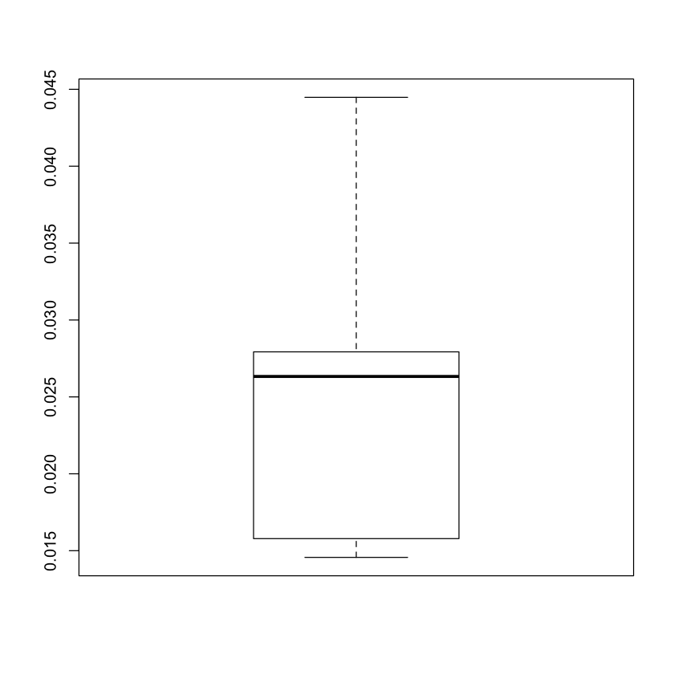

```r
boxplot(MAPE_values)
```

As we can see both from the individual MAPE values and from the boxplot, the **smallest MAPE** value comes from the last model in Part D where we have trained penalized regression models with **L1 penalty for each hour**. The **second smallest MAPE** value is obtained from the model in Part C where we have trained the model with **linear regression for each hour**. The biggest MAPE value is observed in the case of naive forecast where we used the consumption values of two days ago. Lag168 naive forecast provided smaller MAPE than lag48 because the consumption habits are more similar in the same day of the week.

Therefore, we can conclude that using the penalized regression model with L1 penalty for each hour gives the best result. It also makes sense to use the linear regression model for each hour.